# Lab 3 - Data visualization

## Exercise 3: Scatter plots [don’t include in your homework file]

Is there an association with the size of a dandelion rosette and the number of leaves on a dandelion rosette (e.g. do dandelions with larger rosettes have more leaves?).

Both of these variables are numerical, so make a scatterplot to answer this question!

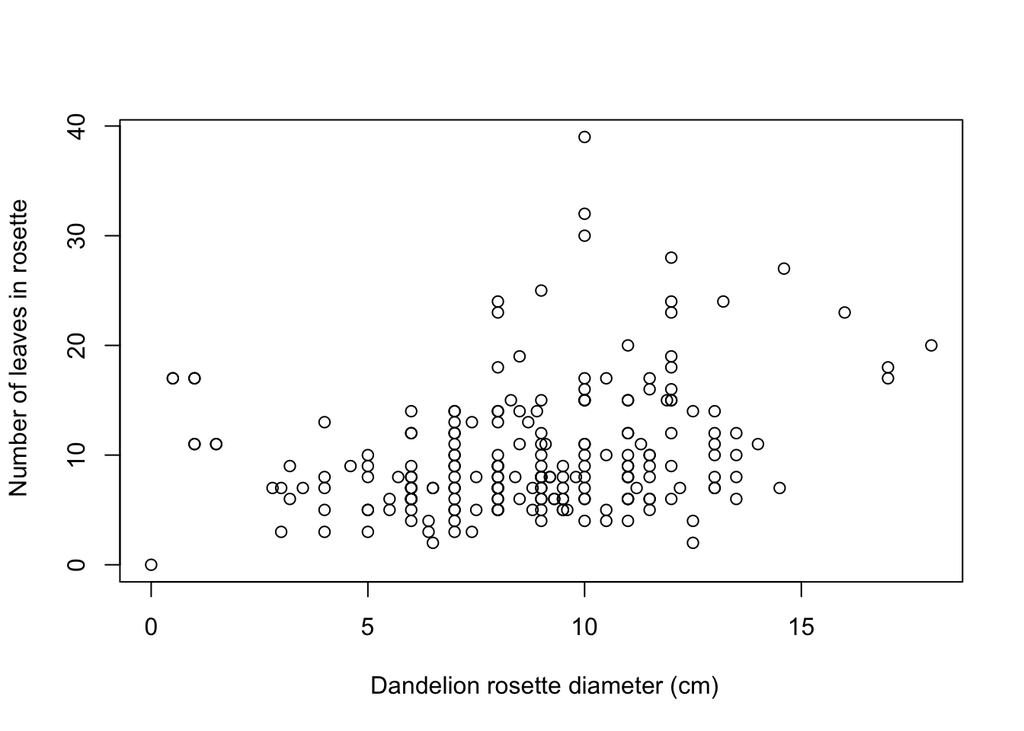

```r
# make a scatterplot

# Method 1
plot(num_leaves_in_rosette ~ dand_rosette_diam_cm, # stating dependent and independent variable
     data = plant, # stating the data set you're using
     xlab = ' Dandelion rosette diameter (cm)', # title
     ylab = ' Number of leaves in rosette') # title
```

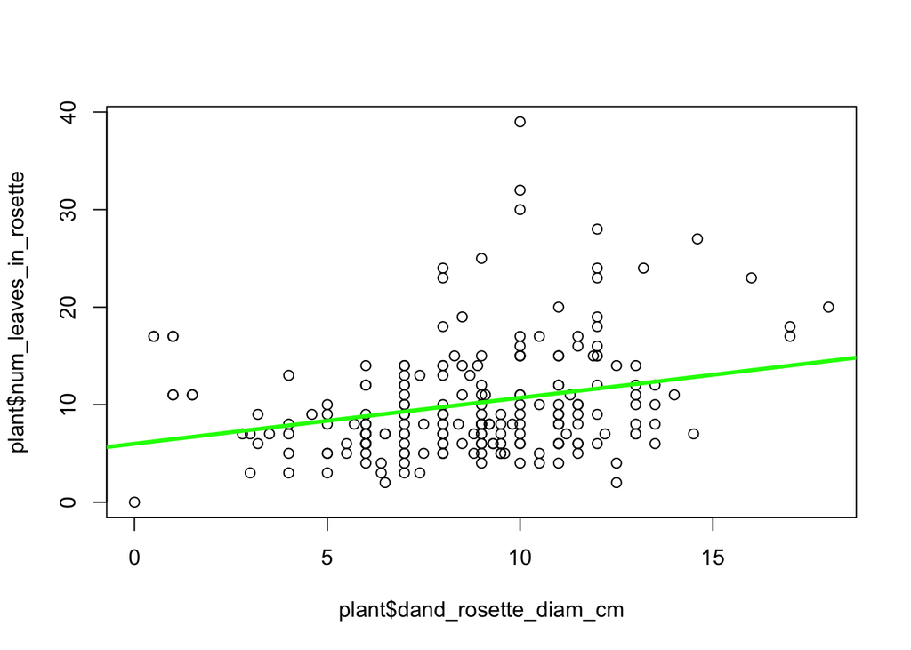

```r
# Method 2
plot(plant$num_leaves_in_rosette ~ plant$dand_rosette_diam_cm)

# now overlay a least squares line to get an idea of the trend
# run a linear regression
fit <- lm(num_leaves_in_rosette ~ dand_rosette_diam_cm, data = plant)
abline(fit, col = 'green', lwd = 3) # lwd = line width
```

## Homework Question 3

We also might expect that the percent cover in a quadrat to vary with the distance to the nearest tree.

Make a scatterplot to explore this relationship using the variables dist_from_tree_m and percent_cover.

You should have 1 plot.

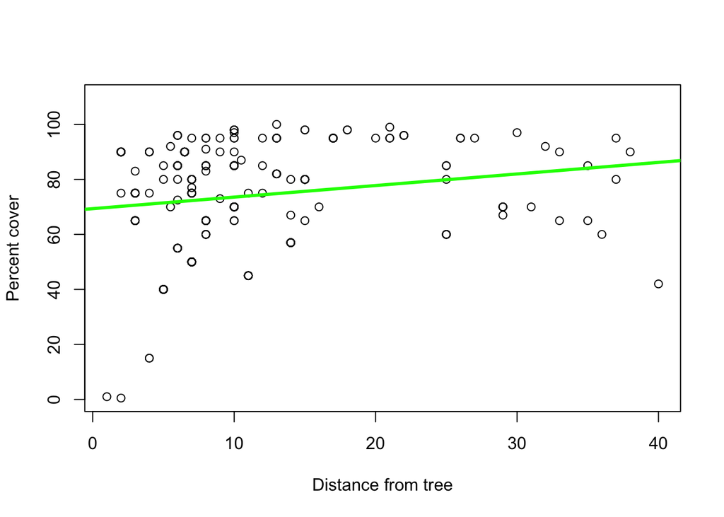

```r
## A) What trend do you notice in the data? Is the linear trend line (green) a good representation of this trend?

# make a scatter plot
plot(plant$percent_cover ~ plant$dist_from_tree_m, xlab="Distance from tree",  ylab= "Percent cover",
     ylim = c(0, 110)) # extended coordinates
# add a linear regression line `lm` function
fit <- lm(plant$percent_cover ~ plant$dist_from_tree_m, data=plant)
abline(fit,col="green", lwd = 3)
```

```r
## ANSWER: As we increase the distance from the nearest tree we see an increase in the percent cover. However, the linear trend line is not a good representation of this trend. The trend looks distinctly non-linear and there is substantial variation in the data. Just because R fitted a linear trend line doesn't mean that a line is the best fit. Even looking just looking at the slope of the line, we can tell it's a small relationship. Thus indicating that there is a weak to possibly no linear relationship.



## B) WHat is the explanatory variable (x-axis)? What is the response variable (y-axis)?

## ANSWER: The explanatory variable is `dist_from_tree_m` and the response variable is `percent_cover`.
```